# The m-format Constellation User Manual

## `mnemonic gen-man`

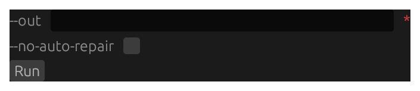

mnemonic gen-man — GUI form screenshot (dark theme, 2x)

Structural render of the `mnemonic gen-man` form — every flag and positional with its control kind and on-load default value (secret fields masked).

```
[ mnemonic > gen-man ]
  --out             path  (required) -> <empty>
  --no-auto-repair  checkbox  -> [ ] off
  [ Run ]
```

## `mnemonic import-wallet`

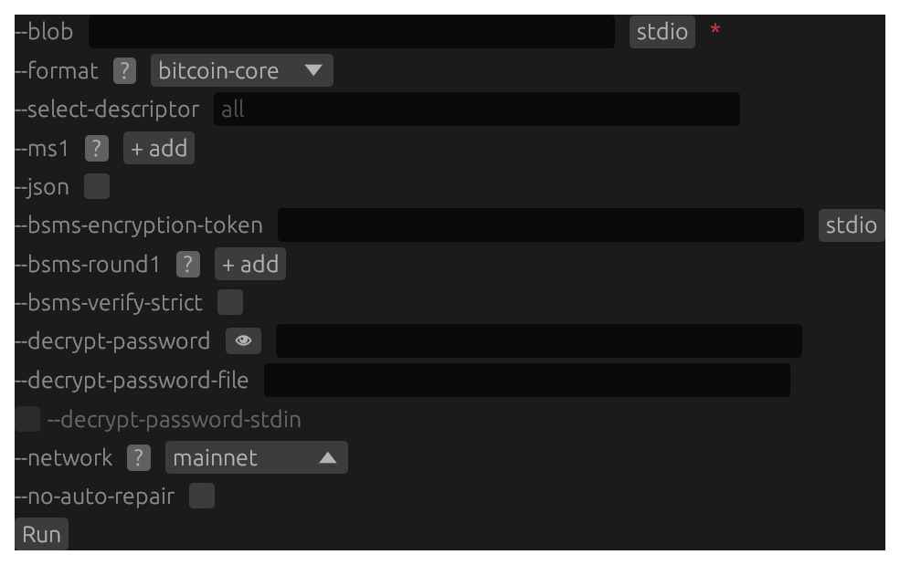

mnemonic import-wallet — GUI form screenshot (dark theme, 2x)

Structural render of the `mnemonic import-wallet` form — every flag and positional with its control kind and on-load default value (secret fields masked).

```
[ mnemonic > import-wallet ]
  --blob                    path(stdio)  (required) -> <empty>
  --format                  dropdown[bitcoin-core,bsms,coldcard,coldcard-multisig,descriptor,electrum,jade,sparrow,specter]  -> bitcoin-core
  --select-descriptor       text  -> <hint:all>
  --ms1                     text  (secret, repeating) -> <masked> [reveal]
  --json                    checkbox  -> [ ] off
  --bsms-encryption-token   path(stdio)  -> <empty>
  --bsms-round1             path  (repeating) -> <empty>
  --bsms-verify-strict      checkbox  -> [ ] off
  --decrypt-password        text  (secret) -> <masked> [reveal]
  --decrypt-password-file   path  -> <empty>
  --decrypt-password-stdin  checkbox  (secret) -> [ ] off [disabled]
  --network                 dropdown[mainnet,testnet,signet,regtest]  -> mainnet
  --no-auto-repair          checkbox  -> [ ] off
  [ slot editor: 0 rows ]
  [ Run ]
```

## `mnemonic inspect`

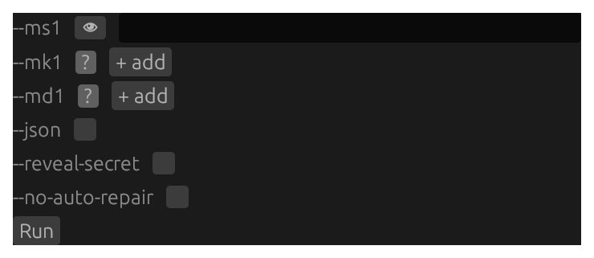

mnemonic inspect — GUI form screenshot (dark theme, 2x)

Structural render of the `mnemonic inspect` form — every flag and positional with its control kind and on-load default value (secret fields masked).

```
[ mnemonic > inspect ]
  --ms1             text  (required, secret) -> <masked> [reveal]
  --mk1             text  (required, repeating) -> <empty>
  --md1             text  (required, repeating) -> <empty>
  --json            checkbox  -> [ ] off
  --reveal-secret   checkbox  -> [ ] off
  --no-auto-repair  checkbox  -> [ ] off
  [ Run ]
```

## `mnemonic ms-shares-combine`

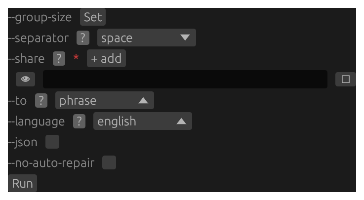

mnemonic ms-shares-combine — GUI form screenshot (dark theme, 2x)

Structural render of the `mnemonic ms-shares-combine` form — every flag and positional with its control kind and on-load default value (secret fields masked).

```
[ mnemonic > ms-shares-combine ]
  --group-size      number  -> <unset>
  --separator       dropdown[space,hyphen,comma]  -> space
  --share           text  (required, secret, repeating) -> <masked> [reveal]
  --to              dropdown[phrase,entropy,ms1]  -> phrase
  --language        dropdown[english,simplifiedchinese,traditionalchinese,czech,french,italian,japanese,korean,portuguese,spanish]  -> english
  --json            checkbox  -> [ ] off
  --no-auto-repair  checkbox  -> [ ] off
  [ Run ]
```

## `mnemonic ms-shares-split`

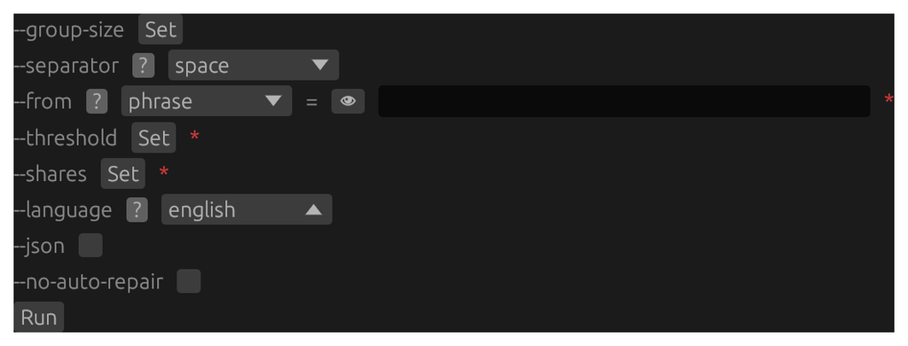

mnemonic ms-shares-split — GUI form screenshot (dark theme, 2x)

Structural render of the `mnemonic ms-shares-split` form — every flag and positional with its control kind and on-load default value (secret fields masked).

```
[ mnemonic > ms-shares-split ]
  --group-size      number  -> <unset>
  --separator       dropdown[space,hyphen,comma]  -> space
  --from            composite[phrase,entropy]  (required) -> phrase=<empty>
  --threshold       number  (required) -> <unset>
  --shares          number  (required) -> <unset>
  --language        dropdown[english,simplifiedchinese,traditionalchinese,czech,french,italian,japanese,korean,portuguese,spanish]  -> english
  --json            checkbox  -> [ ] off
  --no-auto-repair  checkbox  -> [ ] off
  [ Run ]
```

## `mnemonic nostr`

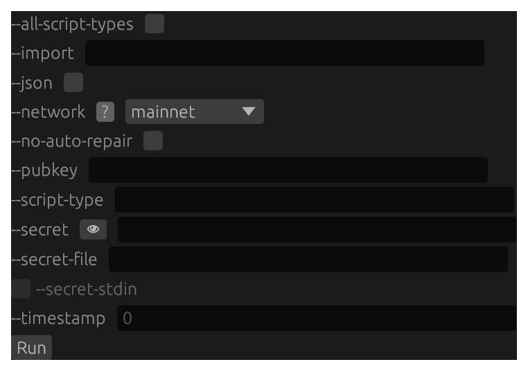

mnemonic nostr — GUI form screenshot (dark theme, 2x)

Structural render of the `mnemonic nostr` form — every flag and positional with its control kind and on-load default value (secret fields masked).

```
[ mnemonic > nostr ]
  --all-script-types  checkbox  -> [ ] off
  --import            text  -> <empty>
  --json              checkbox  -> [ ] off
  --network           dropdown[mainnet,testnet,signet,regtest]  -> mainnet
  --no-auto-repair    checkbox  -> [ ] off
  --pubkey            text  -> <empty>
  --script-type       text  -> <empty>
  --secret            text  (secret) -> <masked> [reveal]
  --secret-file       path  -> <empty>
  --secret-stdin      checkbox  (secret) -> [ ] off [disabled]
  --timestamp         text  -> <hint:0>
  [ Run ]
```

## `mnemonic repair`

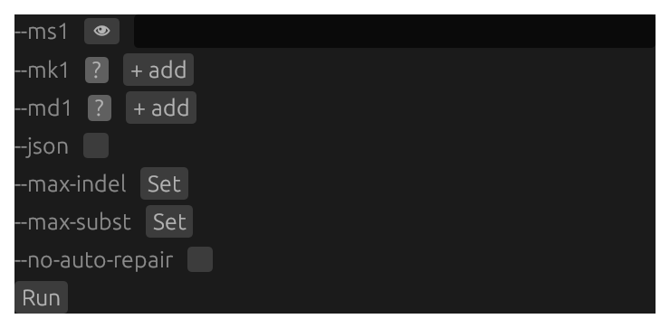

mnemonic repair — GUI form screenshot (dark theme, 2x)

Structural render of the `mnemonic repair` form — every flag and positional with its control kind and on-load default value (secret fields masked).

```
[ mnemonic > repair ]
  --ms1             text  (required, secret) -> <masked> [reveal]
  --mk1             text  (required, repeating) -> <empty>
  --md1             text  (required, repeating) -> <empty>
  --json            checkbox  -> [ ] off
  --max-indel       number  -> <unset>
  --max-subst       number  -> <unset>
  --no-auto-repair  checkbox  -> [ ] off
  [ Run ]
```

## `mnemonic restore`

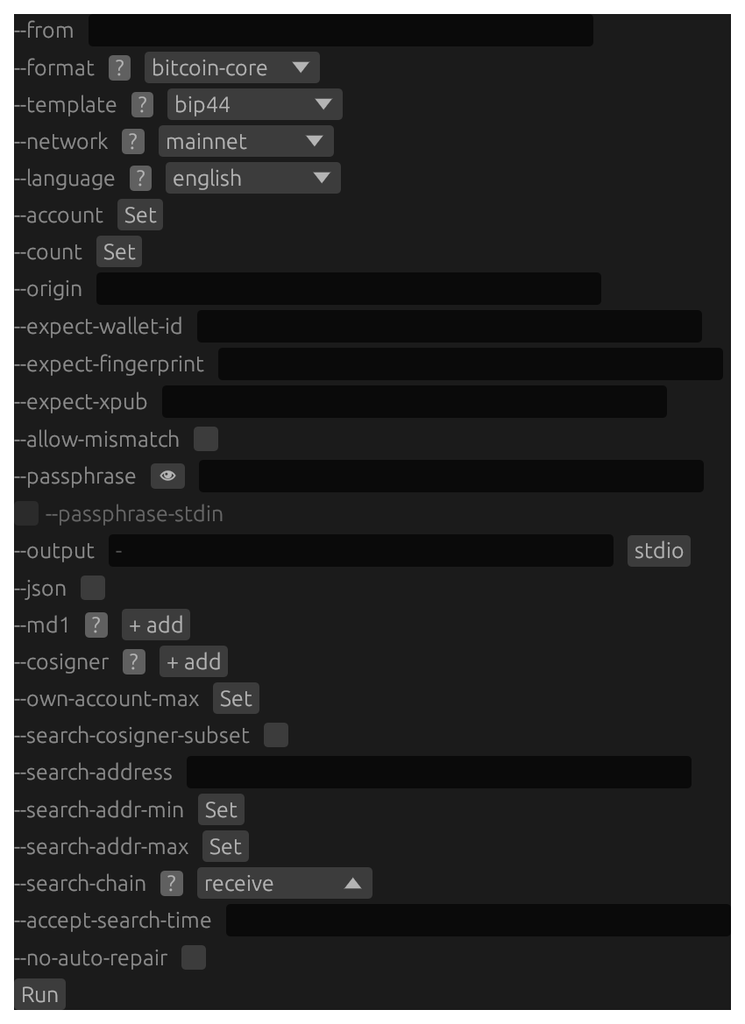

mnemonic restore — GUI form screenshot (dark theme, 2x)

Structural render of the `mnemonic restore` form — every flag and positional with its control kind and on-load default value (secret fields masked).

```
[ mnemonic > restore ]
  --from                    text  (required) -> <empty>
  --format                  dropdown[bitcoin-core,bip388,coldcard,coldcard-multisig,jade,sparrow,specter,electrum,green,bsms,descriptor]  -> bitcoin-core
  --template                dropdown[bip44,bip49,bip84,bip86,wsh-multi,wsh-sortedmulti,sh-wsh-multi,sh-wsh-sortedmulti,tr-multi-a,tr-sortedmulti-a,(none)]  -> bip44
  --network                 dropdown[mainnet,testnet,signet,regtest]  -> mainnet
  --language                dropdown[english,simplifiedchinese,traditionalchinese,czech,french,italian,japanese,korean,portuguese,spanish]  -> english
  --account                 number  -> <unset>
  --count                   number  -> <unset>
  --origin                  text  -> <empty>
  --expect-wallet-id        text  -> <empty>
  --expect-fingerprint      text  -> <empty>
  --expect-xpub             text  -> <empty>
  --allow-mismatch          checkbox  -> [ ] off
  --passphrase              text  (secret) -> <masked> [reveal]
  --passphrase-stdin        checkbox  (secret) -> [ ] off [disabled]
  --output                  path(stdio)  -> <hint:->
  --json                    checkbox  -> [ ] off
  --md1                     text  (repeating) -> <empty>
  --cosigner                text  (repeating) -> <empty>
  --own-account-max         number  -> <unset>
  --search-cosigner-subset  checkbox  -> [ ] off
  --search-address          text  -> <empty>
  --search-addr-min         number  -> <unset>
  --search-addr-max         number  -> <unset>
  --search-chain            dropdown[receive,change,both]  -> receive
  --accept-search-time      text  -> <empty>
  --no-auto-repair          checkbox  -> [ ] off
  [ Run ]
```

## `mnemonic seed-xor-combine`

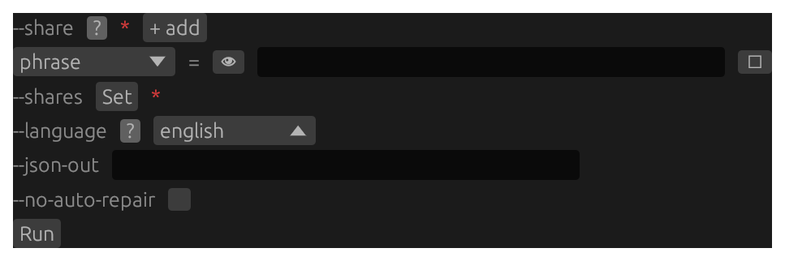

mnemonic seed-xor-combine — GUI form screenshot (dark theme, 2x)

Structural render of the `mnemonic seed-xor-combine` form — every flag and positional with its control kind and on-load default value (secret fields masked).

```
[ mnemonic > seed-xor-combine ]
  --share           composite[phrase]  (required, secret, repeating) -> <masked> [reveal]
  --shares          number  (required) -> <unset>
  --language        dropdown[english,simplifiedchinese,traditionalchinese,czech,french,italian,japanese,korean,portuguese,spanish]  -> english
  --json-out        path  -> <empty>
  --no-auto-repair  checkbox  -> [ ] off
  [ Run ]
```

## `mnemonic seed-xor-split`

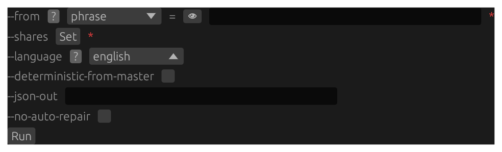

mnemonic seed-xor-split — GUI form screenshot (dark theme, 2x)

Structural render of the `mnemonic seed-xor-split` form — every flag and positional with its control kind and on-load default value (secret fields masked).

```
[ mnemonic > seed-xor-split ]
  --from                       composite[phrase]  (required) -> phrase=<empty>
  --shares                     number  (required) -> <unset>
  --language                   dropdown[english,simplifiedchinese,traditionalchinese,czech,french,italian,japanese,korean,portuguese,spanish]  -> english
  --deterministic-from-master  checkbox  -> [ ] off
  --json-out                   path  -> <empty>
  --no-auto-repair             checkbox  -> [ ] off
  [ Run ]
```

## `mnemonic seedqr-decode`

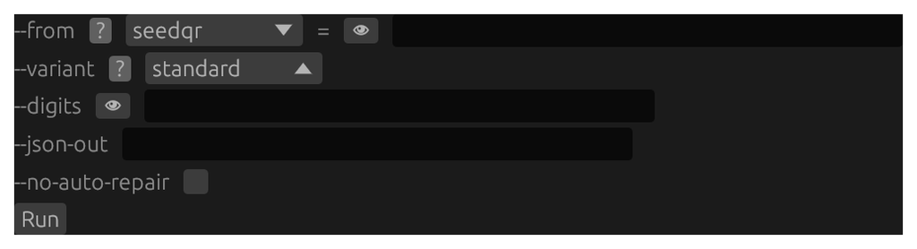

mnemonic seedqr-decode — GUI form screenshot (dark theme, 2x)

Structural render of the `mnemonic seedqr-decode` form — every flag and positional with its control kind and on-load default value (secret fields masked).

```
[ mnemonic > seedqr-decode ]
  --from            composite[seedqr]  -> seedqr=<empty>
  --variant         dropdown[standard,compact]  -> standard
  --digits          text  (secret) -> <masked> [reveal]
  --json-out        path  -> <empty>
  --no-auto-repair  checkbox  -> [ ] off
  [ Run ]
```

## `mnemonic seedqr-encode`

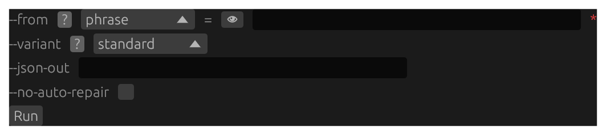

mnemonic seedqr-encode — GUI form screenshot (dark theme, 2x)

Structural render of the `mnemonic seedqr-encode` form — every flag and positional with its control kind and on-load default value (secret fields masked).

```
[ mnemonic > seedqr-encode ]
  --from            composite[phrase]  (required) -> phrase=<empty>
  --variant         dropdown[standard,compact]  -> standard
  --json-out        path  -> <empty>
  --no-auto-repair  checkbox  -> [ ] off
  [ Run ]
```

## `mnemonic silent-payment`

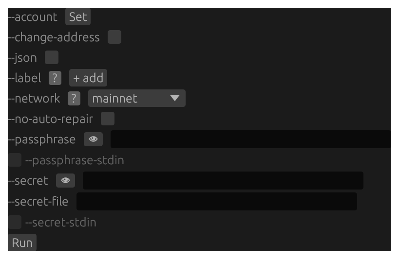

mnemonic silent-payment — GUI form screenshot (dark theme, 2x)

Structural render of the `mnemonic silent-payment` form — every flag and positional with its control kind and on-load default value (secret fields masked).

```
[ mnemonic > silent-payment ]
  --account           number  -> <unset>
  --change-address    checkbox  -> [ ] off
  --json              checkbox  -> [ ] off
  --label             number  (repeating) -> <unset>
  --network           dropdown[mainnet,testnet,signet,regtest]  -> mainnet
  --no-auto-repair    checkbox  -> [ ] off
  --passphrase        text  (secret) -> <masked> [reveal]
  --passphrase-stdin  checkbox  (secret) -> [ ] off [disabled]
  --secret            text  (secret) -> <masked> [reveal]
  --secret-file       path  -> <empty>
  --secret-stdin      checkbox  (secret) -> [ ] off [disabled]
  [ Run ]
```

## `mnemonic slip39-combine`

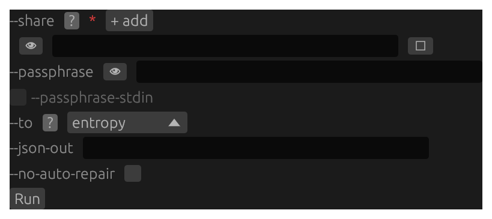

mnemonic slip39-combine — GUI form screenshot (dark theme, 2x)

Structural render of the `mnemonic slip39-combine` form — every flag and positional with its control kind and on-load default value (secret fields masked).

```
[ mnemonic > slip39-combine ]
  --share             text  (required, secret, repeating) -> <masked> [reveal]
  --passphrase        text  (secret) -> <masked> [reveal]
  --passphrase-stdin  checkbox  (secret) -> [ ] off [disabled]
  --to                dropdown[entropy,phrase]  -> entropy
  --json-out          path  -> <empty>
  --no-auto-repair    checkbox  -> [ ] off
  [ Run ]
```

## `mnemonic slip39-split`

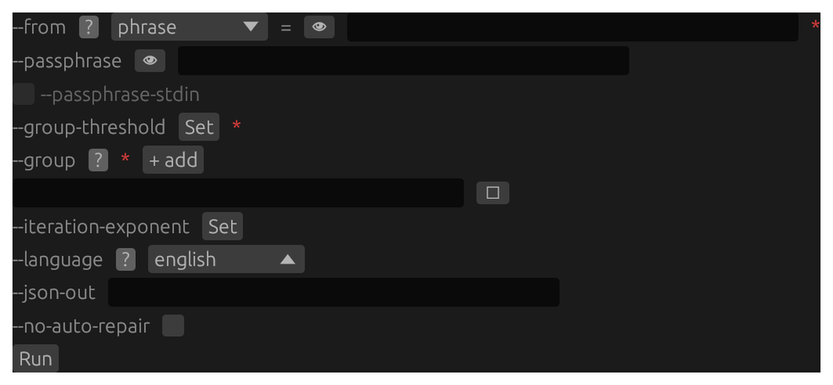

mnemonic slip39-split — GUI form screenshot (dark theme, 2x)

Structural render of the `mnemonic slip39-split` form — every flag and positional with its control kind and on-load default value (secret fields masked).

```
[ mnemonic > slip39-split ]
  --from                composite[phrase,entropy]  (required) -> phrase=<empty>
  --passphrase          text  (secret) -> <masked> [reveal]
  --passphrase-stdin    checkbox  (secret) -> [ ] off [disabled]
  --group-threshold     number  (required) -> <unset>
  --group               text  (required, repeating) -> <empty>
  --iteration-exponent  number  -> <unset>
  --language            dropdown[english,simplifiedchinese,traditionalchinese,czech,french,italian,japanese,korean,portuguese,spanish]  -> english
  --json-out            path  -> <empty>
  --no-auto-repair      checkbox  -> [ ] off
  [ Run ]
```

## `mnemonic verify-bundle`

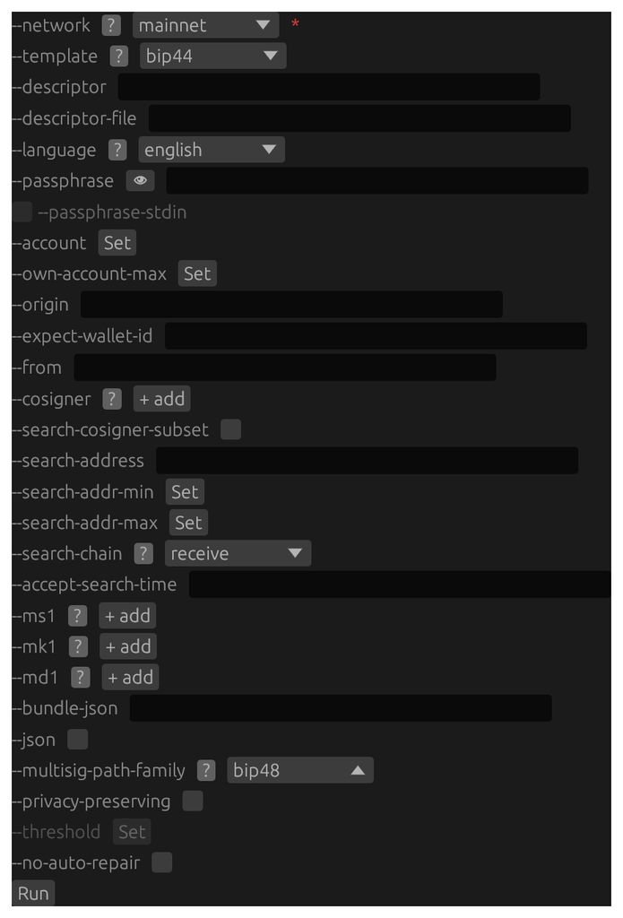

mnemonic verify-bundle — GUI form screenshot (dark theme, 2x)

Structural render of the `mnemonic verify-bundle` form — every flag and positional with its control kind and on-load default value (secret fields masked).

```
[ mnemonic > verify-bundle ]
  --network                 dropdown[mainnet,testnet,signet,regtest]  (required) -> mainnet
  --template                dropdown[bip44,bip49,bip84,bip86,wsh-multi,wsh-sortedmulti,sh-wsh-multi,sh-wsh-sortedmulti,tr-multi-a,tr-sortedmulti-a]  (required) -> bip44
  --descriptor              text  -> <empty>
  --descriptor-file         path  -> <empty>
  --language                dropdown[english,simplifiedchinese,traditionalchinese,czech,french,italian,japanese,korean,portuguese,spanish]  -> english
  --passphrase              text  (secret) -> <masked> [reveal]
  --passphrase-stdin        checkbox  (secret) -> [ ] off [disabled]
  --account                 number  -> <unset>
  --own-account-max         number  -> <unset>
  --origin                  text  -> <empty>
  --expect-wallet-id        text  -> <empty>
  --from                    text  -> <empty>
  --cosigner                text  (repeating) -> <empty>
  --search-cosigner-subset  checkbox  -> [ ] off
  --search-address          text  -> <empty>
  --search-addr-min         number  -> <unset>
  --search-addr-max         number  -> <unset>
  --search-chain            dropdown[receive,change,both]  -> receive
  --accept-search-time      text  -> <empty>
  --ms1                     text  (secret, repeating) -> <masked> [reveal]
  --mk1                     text  (required, repeating) -> <empty>
  --md1                     text  (required, repeating) -> <empty>
  --bundle-json             path  -> <empty>
  --json                    checkbox  -> [ ] off
  --multisig-path-family    dropdown[bip48,bip87]  -> bip48
  --privacy-preserving      checkbox  -> [ ] off
  --threshold               number  -> <unset> [disabled]
  --no-auto-repair          checkbox  -> [ ] off
  [ slot editor: 0 rows ]
  [ Run ]
```

## `mnemonic verify-message`

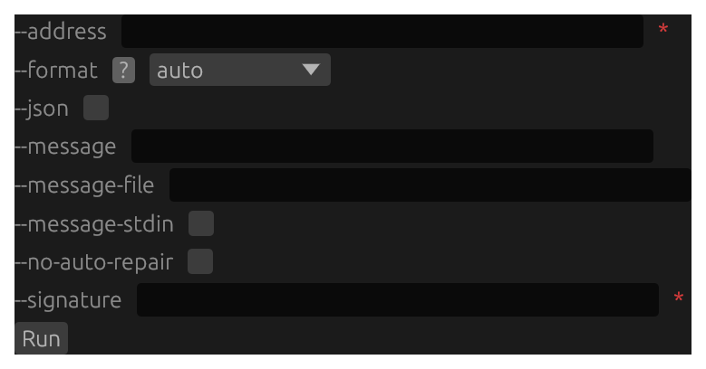

mnemonic verify-message — GUI form screenshot (dark theme, 2x)

Structural render of the `mnemonic verify-message` form — every flag and positional with its control kind and on-load default value (secret fields masked).

```
[ mnemonic > verify-message ]
  --address         text  (required) -> <empty>
  --format          dropdown[auto,legacy,bip322]  -> auto
  --json            checkbox  -> [ ] off
  --message         text  -> <empty>
  --message-file    path  -> <empty>
  --message-stdin   checkbox  -> [ ] off
  --no-auto-repair  checkbox  -> [ ] off
  --signature       text  (required) -> <empty>
  [ Run ]
```

## `mnemonic word-card`

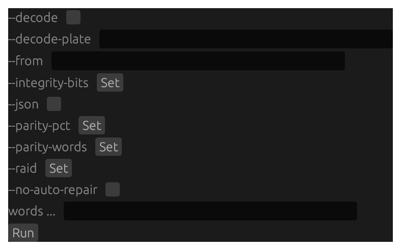

mnemonic word-card — GUI form screenshot (dark theme, 2x)

Structural render of the `mnemonic word-card` form — every flag and positional with its control kind and on-load default value (secret fields masked).

```
[ mnemonic > word-card ]
  --decode          checkbox  -> [ ] off
  --decode-plate    text  -> <empty>
  --from            text  -> <empty>
  --integrity-bits  number  -> <unset>
  --json            checkbox  -> [ ] off
  --parity-pct      number  -> <unset>
  --parity-words    number  -> <unset>
  --raid            number  -> <unset>
  --no-auto-repair  checkbox  -> [ ] off
  words             positional...  -> <empty>
  [ Run ]
```

## `mnemonic xpub-search-account-of-descriptor`

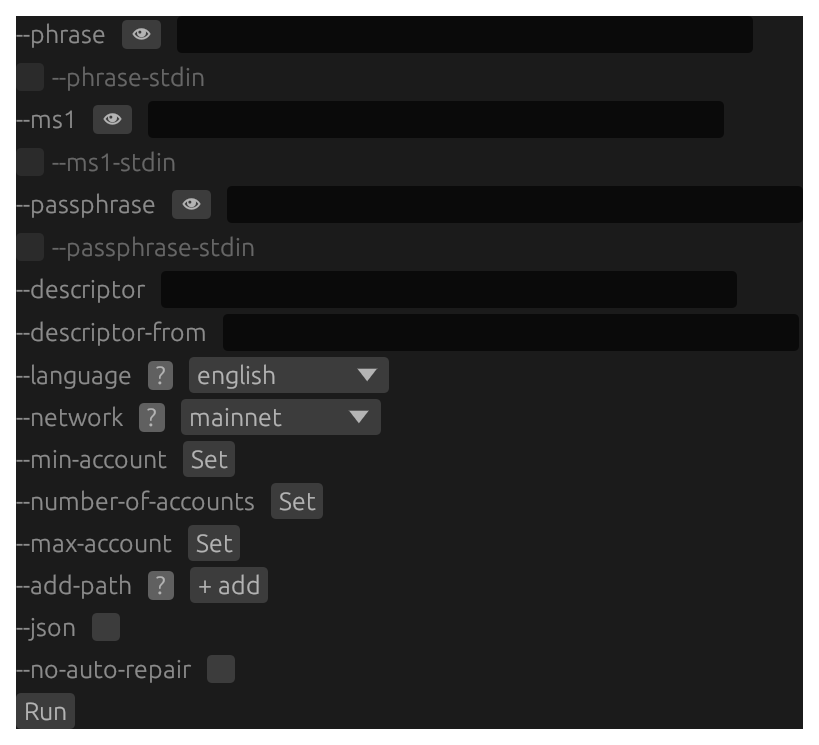

mnemonic xpub-search-account-of-descriptor — GUI form screenshot (dark theme, 2x)

Structural render of the `mnemonic xpub-search-account-of-descriptor` form — every flag and positional with its control kind and on-load default value (secret fields masked).

```
[ mnemonic > xpub-search-account-of-descriptor ]
  --phrase              text  (secret) -> <masked> [reveal]
  --phrase-stdin        checkbox  (secret) -> [ ] off [disabled]
  --ms1                 text  (secret) -> <masked> [reveal]
  --ms1-stdin           checkbox  (secret) -> [ ] off [disabled]
  --passphrase          text  (secret) -> <masked> [reveal]
  --passphrase-stdin    checkbox  (secret) -> [ ] off [disabled]
  --descriptor          text  -> <empty>
  --descriptor-from     text  -> <empty>
  --language            dropdown[english,simplifiedchinese,traditionalchinese,czech,french,italian,japanese,korean,portuguese,spanish]  -> english
  --network             dropdown[mainnet,testnet,signet,regtest]  -> mainnet
  --min-account         number  -> <unset>
  --number-of-accounts  number  -> <unset>
  --max-account         number  -> <unset>
  --add-path            text  (repeating) -> <empty>
  --json                checkbox  -> [ ] off
  --no-auto-repair      checkbox  -> [ ] off
  [ Run ]
```

## `mnemonic xpub-search-address-of-xpub`

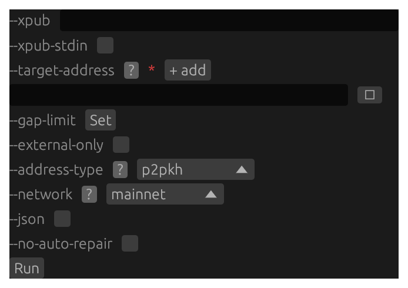

mnemonic xpub-search-address-of-xpub — GUI form screenshot (dark theme, 2x)

Structural render of the `mnemonic xpub-search-address-of-xpub` form — every flag and positional with its control kind and on-load default value (secret fields masked).

```
[ mnemonic > xpub-search-address-of-xpub ]
  --xpub            text  -> <empty>
  --xpub-stdin      checkbox  -> [ ] off
  --target-address  text  (required, repeating) -> <empty>
  --gap-limit       number  -> <unset>
  --external-only   checkbox  -> [ ] off
  --address-type    dropdown[p2pkh,p2sh-p2wpkh,p2wpkh,p2tr]  -> p2pkh
  --network         dropdown[mainnet,testnet,signet,regtest]  -> mainnet
  --json            checkbox  -> [ ] off
  --no-auto-repair  checkbox  -> [ ] off
  [ Run ]
```

## `mnemonic xpub-search-passphrase-of-xpub`

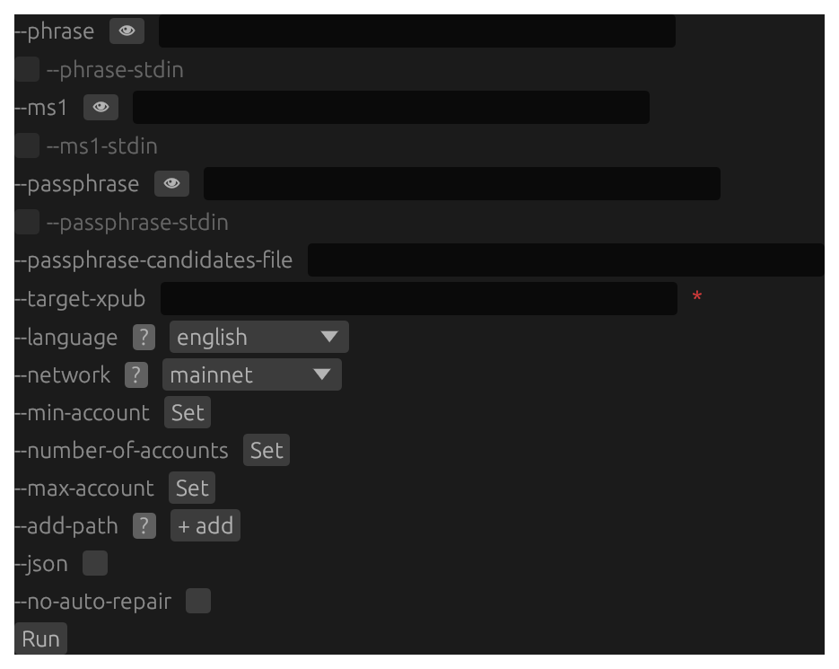

mnemonic xpub-search-passphrase-of-xpub — GUI form screenshot (dark theme, 2x)

Structural render of the `mnemonic xpub-search-passphrase-of-xpub` form — every flag and positional with its control kind and on-load default value (secret fields masked).

```
[ mnemonic > xpub-search-passphrase-of-xpub ]
  --phrase                      text  (secret) -> <masked> [reveal]
  --phrase-stdin                checkbox  (secret) -> [ ] off [disabled]
  --ms1                         text  (secret) -> <masked> [reveal]
  --ms1-stdin                   checkbox  (secret) -> [ ] off [disabled]
  --passphrase                  text  (secret) -> <masked> [reveal]
  --passphrase-stdin            checkbox  (secret) -> [ ] off [disabled]
  --passphrase-candidates-file  path  -> <empty>
  --target-xpub                 text  (required) -> <empty>
  --language                    dropdown[english,simplifiedchinese,traditionalchinese,czech,french,italian,japanese,korean,portuguese,spanish]  -> english
  --network                     dropdown[mainnet,testnet,signet,regtest]  -> mainnet
  --min-account                 number  -> <unset>
  --number-of-accounts          number  -> <unset>
  --max-account                 number  -> <unset>
  --add-path                    text  (repeating) -> <empty>
  --json                        checkbox  -> [ ] off
  --no-auto-repair              checkbox  -> [ ] off
  [ Run ]
```

## `mnemonic xpub-search-path-of-xpub`

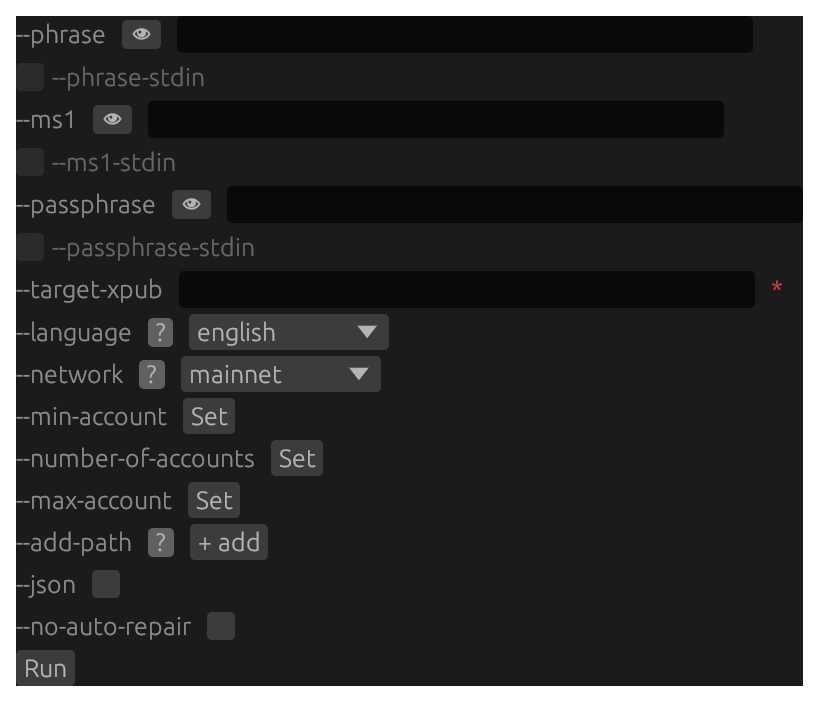

mnemonic xpub-search-path-of-xpub — GUI form screenshot (dark theme, 2x)

Structural render of the `mnemonic xpub-search-path-of-xpub` form — every flag and positional with its control kind and on-load default value (secret fields masked).

```
[ mnemonic > xpub-search-path-of-xpub ]
  --phrase              text  (secret) -> <masked> [reveal]
  --phrase-stdin        checkbox  (secret) -> [ ] off [disabled]
  --ms1                 text  (secret) -> <masked> [reveal]
  --ms1-stdin           checkbox  (secret) -> [ ] off [disabled]
  --passphrase          text  (secret) -> <masked> [reveal]
  --passphrase-stdin    checkbox  (secret) -> [ ] off [disabled]
  --target-xpub         text  (required) -> <empty>
  --language            dropdown[english,simplifiedchinese,traditionalchinese,czech,french,italian,japanese,korean,portuguese,spanish]  -> english
  --network             dropdown[mainnet,testnet,signet,regtest]  -> mainnet
  --min-account         number  -> <unset>
  --number-of-accounts  number  -> <unset>
  --max-account         number  -> <unset>
  --add-path            text  (repeating) -> <empty>
  --json                checkbox  -> [ ] off
  --no-auto-repair      checkbox  -> [ ] off
  [ Run ]
```

# `md` GUI forms

Screenshots and structural form renders for all 10 subcommands on the **`md`** tab. See the GUI Forms reference overview for how to read a screenshot and a render and what `<masked>`, `(required)`, and `[disabled]` mean. Each form’s prose, per-flag reference, and worked example live in its own subcommand chapter, reached from the `> **GUI form:**` cross-link there.

## `md address`

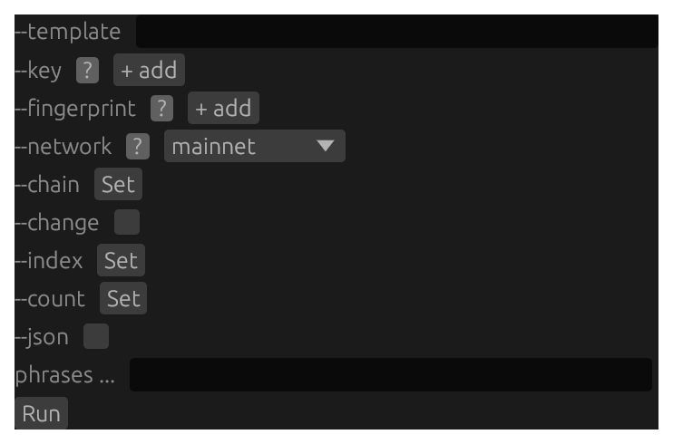

md address — GUI form screenshot (dark theme, 2x)

Structural render of the `md address` form — every flag and positional with its control kind and on-load default value (secret fields masked).

```
[ md > address ]
  --template     text  (required) -> <empty>
  --key          text  (repeating) -> <empty>
  --fingerprint  text  (repeating) -> <empty>
  --network      dropdown[mainnet,testnet,signet,regtest]  -> mainnet
  --chain        number  -> <unset>
  --change       checkbox  -> [ ] off
  --index        number  -> <unset>
  --count        number  -> <unset>
  --json         checkbox  -> [ ] off
  phrases        positional...  -> <empty>
  [ Run ]
```

## `md bytecode`

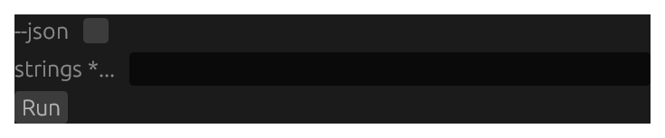

md bytecode — GUI form screenshot (dark theme, 2x)

Structural render of the `md bytecode` form — every flag and positional with its control kind and on-load default value (secret fields masked).

```
[ md > bytecode ]
  --json   checkbox  -> [ ] off
  strings  positional...  (required) -> <empty>
  [ Run ]
```

## `md compile`

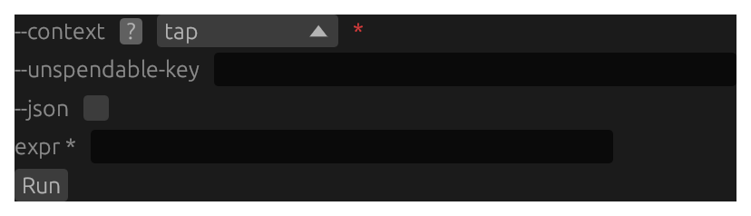

md compile — GUI form screenshot (dark theme, 2x)

Structural render of the `md compile` form — every flag and positional with its control kind and on-load default value (secret fields masked).

```
[ md > compile ]
  --context          dropdown[tap,segwitv0]  (required) -> tap
  --unspendable-key  text  -> <empty>
  --json             checkbox  -> [ ] off
  expr               positional  (required) -> <empty>
  [ Run ]
```

## `md decode`

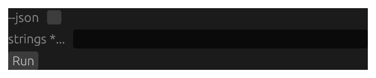

md decode — GUI form screenshot (dark theme, 2x)

Structural render of the `md decode` form — every flag and positional with its control kind and on-load default value (secret fields masked).

```
[ md > decode ]
  --json   checkbox  -> [ ] off
  strings  positional...  (required) -> <empty>
  [ Run ]
```

## `md encode`

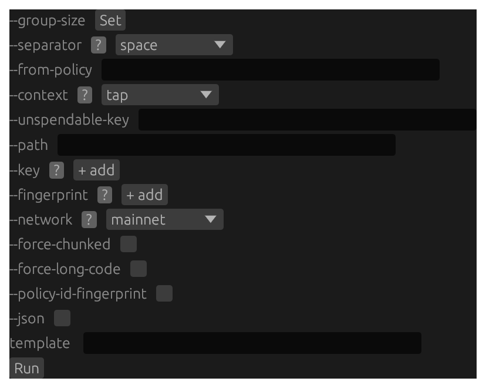

md encode — GUI form screenshot (dark theme, 2x)

Structural render of the `md encode` form — every flag and positional with its control kind and on-load default value (secret fields masked).

```
[ md > encode ]
  --group-size             number  -> <unset>
  --separator              dropdown[space,hyphen,comma]  -> space
  --from-policy            text  (required) -> <empty>
  --context                dropdown[tap,segwitv0]  -> tap
  --unspendable-key        text  -> <empty>
  --path                   text  -> <empty>
  --key                    text  (repeating) -> <empty>
  --fingerprint            text  (repeating) -> <empty>
  --network                dropdown[mainnet,testnet,signet,regtest]  -> mainnet
  --force-chunked          checkbox  -> [ ] off
  --force-long-code        checkbox  -> [ ] off
  --policy-id-fingerprint  checkbox  -> [ ] off
  --json                   checkbox  -> [ ] off
  template                 positional  -> <empty>
  [ Run ]
```

## `md gen-man`

Structural render of the `md gen-man` form — every flag and positional with its control kind and on-load default value (secret fields masked).

```
[ md > gen-man ]
  --out  path  (required) -> <empty>
  [ Run ]
```

## `md inspect`

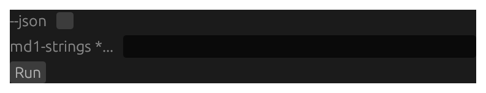

md inspect — GUI form screenshot (dark theme, 2x)

Structural render of the `md inspect` form — every flag and positional with its control kind and on-load default value (secret fields masked).

```
[ md > inspect ]
  --json       checkbox  -> [ ] off
  md1-strings  positional...  (required) -> <empty>
  [ Run ]
```

## `md repair`

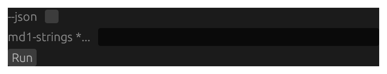

md repair — GUI form screenshot (dark theme, 2x)

Structural render of the `md repair` form — every flag and positional with its control kind and on-load default value (secret fields masked).

```
[ md > repair ]
  --json       checkbox  -> [ ] off
  md1-strings  positional...  (required) -> <empty>
  [ Run ]
```

## `md vectors`

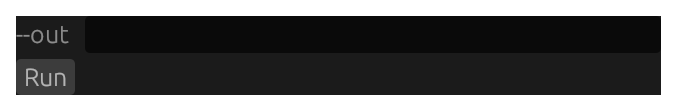

md vectors — GUI form screenshot (dark theme, 2x)

Structural render of the `md vectors` form — every flag and positional with its control kind and on-load default value (secret fields masked).

```
[ md > vectors ]
  --out  path  -> <empty>
  [ Run ]
```

## `md verify`

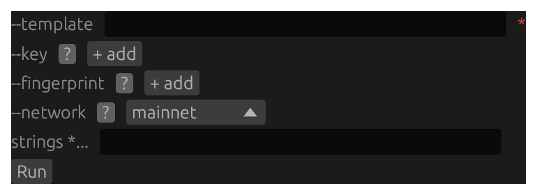

md verify — GUI form screenshot (dark theme, 2x)

Structural render of the `md verify` form — every flag and positional with its control kind and on-load default value (secret fields masked).

```
[ md > verify ]
  --template     text  (required) -> <empty>
  --key          text  (repeating) -> <empty>
  --fingerprint  text  (repeating) -> <empty>
  --network      dropdown[mainnet,testnet,signet,regtest]  -> mainnet
  strings        positional...  (required) -> <empty>
  [ Run ]
```

# `ms` GUI forms

Screenshots and structural form renders for all 10 subcommands on the **`ms`** tab. See the GUI Forms reference overview for how to read a screenshot and a render and what `<masked>`, `(required)`, and `[disabled]` mean. Each form’s prose, per-flag reference, and worked example live in its own subcommand chapter, reached from the `> **GUI form:**` cross-link there.

## `ms combine`

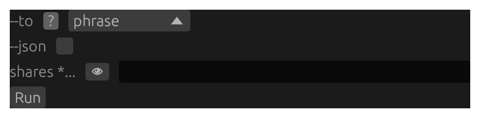

ms combine — GUI form screenshot (dark theme, 2x)

Structural render of the `ms combine` form — every flag and positional with its control kind and on-load default value (secret fields masked).

```
[ ms > combine ]
  --to    dropdown[phrase,entropy,ms1]  -> phrase
  --json  checkbox  -> [ ] off
  shares  positional...  (required, secret) -> <masked> [reveal]
  [ Run ]
```

## `ms decode`

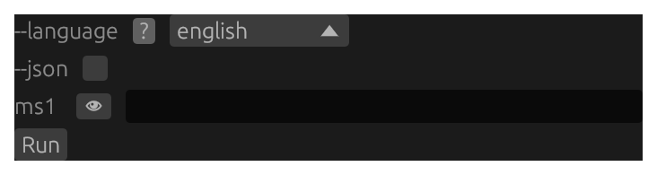

ms decode — GUI form screenshot (dark theme, 2x)

Structural render of the `ms decode` form — every flag and positional with its control kind and on-load default value (secret fields masked).

```
[ ms > decode ]
  --language  dropdown[english,japanese,korean,spanish,chinese-simplified,chinese-traditional,french,italian,czech,portuguese]  -> english
  --json      checkbox  -> [ ] off
  ms1         positional  (secret) -> <masked> [reveal]
  [ Run ]
```

## `ms derive`

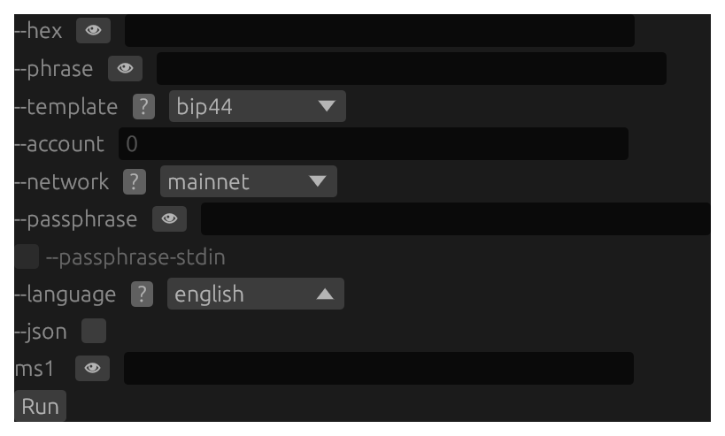

ms derive — GUI form screenshot (dark theme, 2x)

Structural render of the `ms derive` form — every flag and positional with its control kind and on-load default value (secret fields masked).

```
[ ms > derive ]
  --hex               text  (secret) -> <masked> [reveal]
  --phrase            text  (secret) -> <masked> [reveal]
  --template          dropdown[bip44,bip49,bip84,bip86]  -> bip44
  --account           text  -> <hint:0>
  --network           dropdown[mainnet,testnet]  -> mainnet
  --passphrase        text  (secret) -> <masked> [reveal]
  --passphrase-stdin  checkbox  (secret) -> [ ] off [disabled]
  --language          dropdown[english,japanese,korean,spanish,chinese-simplified,chinese-traditional,french,italian,czech,portuguese]  -> english
  --json              checkbox  -> [ ] off
  ms1                 positional  (secret) -> <masked> [reveal]
  [ Run ]
```

## `ms encode`

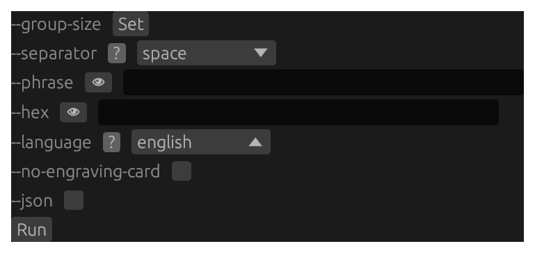

ms encode — GUI form screenshot (dark theme, 2x)

Structural render of the `ms encode` form — every flag and positional with its control kind and on-load default value (secret fields masked).

```
[ ms > encode ]
  --group-size         number  -> <unset>
  --separator          dropdown[space,hyphen,comma]  -> space
  --phrase             text  (required, secret) -> <masked> [reveal]
  --hex                text  (required, secret) -> <masked> [reveal]
  --language           dropdown[english,japanese,korean,spanish,chinese-simplified,chinese-traditional,french,italian,czech,portuguese]  -> english
  --no-engraving-card  checkbox  -> [ ] off
  --json               checkbox  -> [ ] off
  [ Run ]
```

## `ms gen-man`

Structural render of the `ms gen-man` form — every flag and positional with its control kind and on-load default value (secret fields masked).

```
[ ms > gen-man ]
  --out  text  (required) -> <empty>
  [ Run ]
```

## `ms inspect`

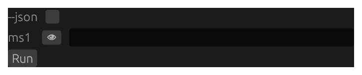

ms inspect — GUI form screenshot (dark theme, 2x)

Structural render of the `ms inspect` form — every flag and positional with its control kind and on-load default value (secret fields masked).

```
[ ms > inspect ]
  --json  checkbox  -> [ ] off
  ms1     positional  (secret) -> <masked> [reveal]
  [ Run ]
```

## `ms repair`

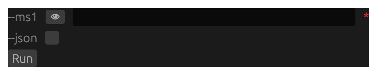

ms repair — GUI form screenshot (dark theme, 2x)

Structural render of the `ms repair` form — every flag and positional with its control kind and on-load default value (secret fields masked).

```
[ ms > repair ]
  --ms1   text  (required, secret) -> <masked> [reveal]
  --json  checkbox  -> [ ] off
  [ Run ]
```